# Legislative & Presidential Election 2014

Fahrozi

6/6/2019

## Exploring Election and Cencus Highly Informative Data Nationally for Indonesia

An Election is one of the main pillars of democracy. it presents the will of the people and determine a country’s leadership.

In Indonesia, elections are highly anticipated,because it provides an opportunity for all people to influence the direction of their country.The results and voting patterns in an election are of great public interest,but often data is not easy to access or work with.This project aims to increase the accessibility of Indonesian election data, which would be particularly beneficial to researchers, journalists and NGOs.

in this project will discuss about Indonesian Legislative Election and Presidential Election 2014. Indonesian Legislative Election were held in Indonesia on 9 april 2014 to elect members of the Regional Representative Council (DPD), Members of People’s Representative Council (DPR) and members of the regional assemblies at the provinces. In Presidential Election were held In Indonesia on 9 july 2014, according to the 2008 election law,the nominations of the candidates for the presidential election may only be made by a party of coalition of parties) which has at least 20% of the seats in the national parliament (the DPR) or which received 25% of national votes in the previous national legislative election for the DPR.

## Import csv files

```r
library(readxl)
Party_in_Legislative_Election <- read_excel("../Data/Party in Legislative Election.xlsx")
```

## Data set party

```
## Observations: 563
## Variables: 3
## $ Names     <chr> "Teuku Riefky Harsa", "Irmawan", "Muhammad Nasir Djami…
## $ PartyNm   <chr> "Partai Demokrat", "Partai Kebangkitan Bangsa", "Parta…
## $ Provinces <chr> "Aceh 1", "Aceh 1", "Aceh 1", "Aceh 1", "Aceh 1", "Ace…
```

| Names | PartyNm | Provinces |
| --- | --- | --- |
| Teuku Riefky Harsa | Partai Demokrat | Aceh 1 |
| Irmawan | Partai Kebangkitan Bangsa | Aceh 1 |
| Muhammad Nasir Djamil | Partai Keadilan Sejahtera | Aceh 1 |
| Bachtiar Aly | Partai NasDem | Aceh 1 |
| Muslim Ayub | Partai Amanat Nasional | Aceh 1 |
| Fadhullah | Partai Gerakan Indonesia Raya | Aceh 1 |

## Party who won the Legislative Election

```r
who_won <- Party_in_Legislative_Election %>%
group_by(PartyNm) %>%
tally() %>%
arrange(desc(n))
who_won %>%
  kable()
```

| PartyNm | n |
| --- | --- |
| Partai Demokrasi Indonesia Perjuangan | 110 |
| Partai Golongan Karya | 90 |
| Partai Gerakan Indonesia Raya | 73 |
| Partai Demokrat | 60 |
| Partai Amanat Nasional | 48 |
| Partai Kebangkitan Bangsa | 48 |
| Partai Keadilan Sejahtera | 41 |
| Partai Persatuan Pembangunan | 40 |
| Partai NasDem | 35 |
| Partai Hati Nurani Rakyat | 16 |
| Parta Demokrasi Indonesia Perjuangan | 1 |
| Partai Nasional Demokrat | 1 |

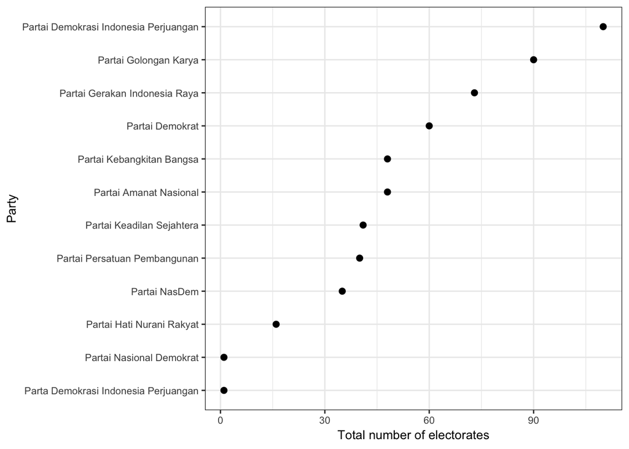

```r
library(ggplot2)
library(scales)
ggplot(who_won,
       aes(reorder(PartyNm, n),
n)) +
geom_point(size = 2)+
coord_flip() +
scale_y_continuous(labels = comma) +
theme_bw() +
ylab("Total number of electorates") +
xlab("Party") +
theme(text = element_text(size=10))
```

## Data set total votes

```r
totalvotes <- read_excel("../Data/totalvotes.xlsx")
glimpse(totalvotes)
```

```
## Observations: 924
## Variables: 3
## $ Provinces <chr> "Aceh 1", "Aceh 1", "Aceh 1", "Aceh 1", "Aceh 1", "Ace…
## $ PartyNm   <chr> "Partai Nasdem", "Partai Kebangkitan Bangsa", "Partai …
## $ Votes     <dbl> 151121, 92905, 105868, 35419, 140954, 184538, 209598, …
```

## Party received the most votes in Legislative Election

```r
totalvotes <- totalvotes %>% mutate(Votes=as.numeric(Votes))
total_votes_for_parties <- totalvotes %>%
  select(PartyNm, Votes) %>%
  group_by(PartyNm) %>%
  summarise(tvotes = sum(Votes)) %>%
  ungroup() %>%
  arrange(desc(tvotes))
total_votes_for_parties %>%
  head %>%
  kable
```

| PartyNm | tvotes |
| --- | --- |
| Partai Demokrasi Indonesia Perjuangan | 23682471 |
| Partai Golongan Karya | 18432312 |
| Partai Gerindra | 14760371 |
| Partai Demokrat | 12561934 |
| Partai Kebangkitan Bangsa | 11298957 |
| Partai Amanat Nasional | 9584961 |

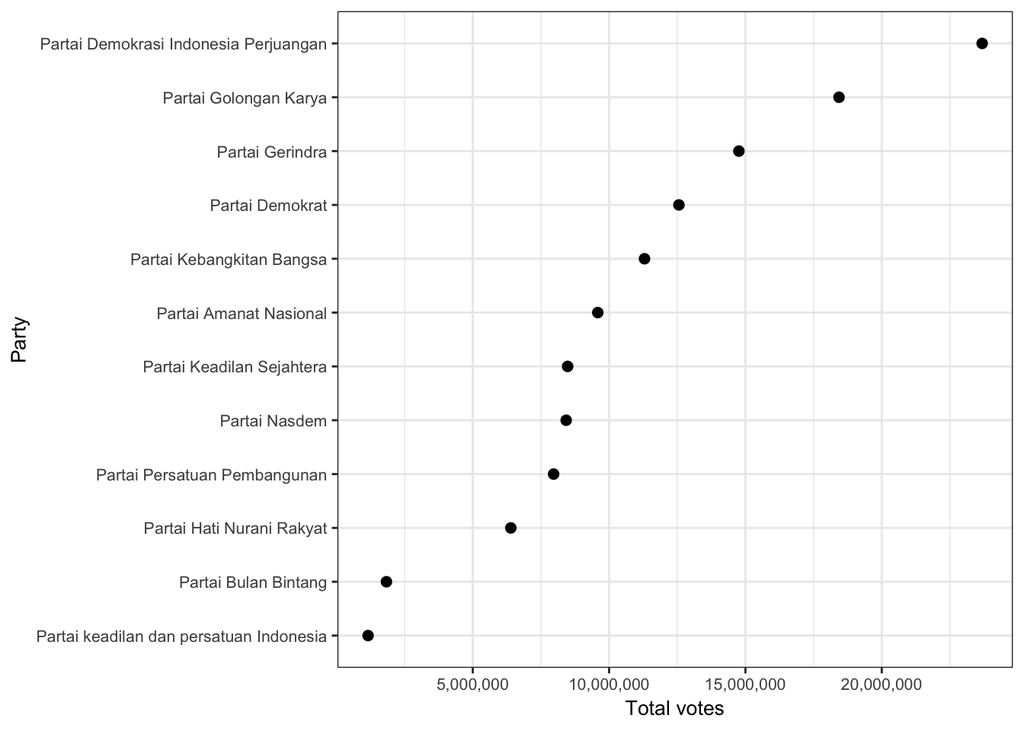

```r
ggplot(total_votes_for_parties,
       aes(reorder(PartyNm, tvotes),
           tvotes)) +
geom_point(size = 2) +
coord_flip() +
scale_y_continuous(labels = comma) +
theme_bw() +
ylab("Total votes") +
xlab("Party") +
theme(text = element_text(size=10))
```

## Party who get many number of seats in Parliament

```r
Totalseats <- read_excel("../Data/Totalseats.xlsx")
glimpse(Totalseats)
```

```
## Observations: 396
## Variables: 3
## $ Provinces  <chr> "Aceh", "Aceh", "Aceh", "Aceh", "Aceh", "Aceh", "Aceh…
## $ PartyNm    <chr> "Partai Nasdem", "Partai Kebangkitan Bangsa", "Partai…
## $ Totalseats <dbl> 2, 1, 1, 1, 2, 2, 2, 1, 1, 0, 0, 0, 3, 1, 3, 4, 4, 4,…
```

```r
Totalseats <- Totalseats %>% mutate(Totseats=as.numeric(Totalseats))
Total_seats_for_parties <- Totalseats %>%
  select(PartyNm, Totseats) %>%
  group_by(PartyNm) %>%
  summarise(tot_seats = sum(Totseats)) %>%
  ungroup() %>%
  arrange(desc(tot_seats))
Total_seats_for_parties %>%
  head %>%
  kable
```

| PartyNm | tot_seats |
| --- | --- |
| Partai Demokrasi Indonesia Perjuangan | 109 |
| Partai Golongan Karya | 91 |
| Partai Gerindra | 74 |
| Partai Demokrat | 60 |
| Partai Amanat Nasional | 50 |
| Partai Kebangkitan Bangsa | 47 |

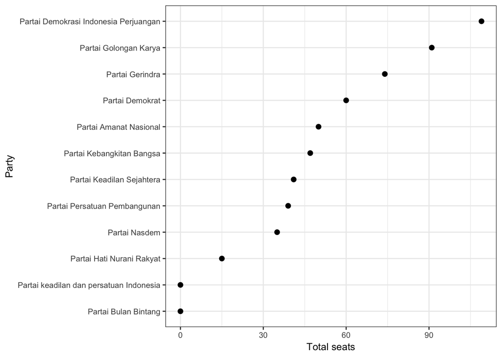

```r
ggplot(Total_seats_for_parties,
       aes(reorder(PartyNm, tot_seats),
           tot_seats)) +
  geom_point(size = 2) +
  coord_flip() +
  scale_y_continuous(labels = comma) +
  theme_bw() +
  ylab("Total seats") +
  xlab("Party") +
  theme(text = element_text(size=10))
```

## Provinces who get many seats in parliament

```r
Total_seats_for_provinces <- Totalseats %>%
  select(Provinces, Totseats) %>%
  group_by(Provinces) %>%
  summarise(tot_seats = sum(Totseats)) %>%
  ungroup() %>%
  arrange(desc(tot_seats))
Total_seats_for_provinces %>%
  head %>%
  kable
```

| Provinces | tot_seats |
| --- | --- |
| Jawa Barat | 91 |
| Jawa Timur | 87 |
| Jawa Tengah | 77 |
| Sumatra Utara | 30 |
| Sulawesi Selatan | 24 |
| Banten | 22 |

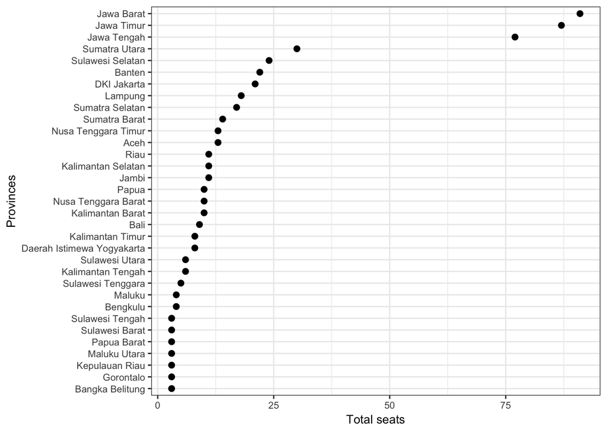

```r
ggplot(Total_seats_for_provinces,
       aes(reorder(Provinces, tot_seats),
           tot_seats)) +
  geom_point(size = 2) +
  coord_flip() +
  scale_y_continuous(labels = comma) +
  theme_bw() +
  ylab("Total seats") +
  xlab("Provinces") +
  theme(text = element_text(size=10))
```